# presentation of shiny app

11/26/2019

## 2017 Car crash data in Allegheny County

Shiny Applicatio Link : https://akz120.shinyapps.io/myapp/ Github Repository Link : https://github.com/akz120/Peer-graded-Assignment-Course-Project-Shiny-Application-and-Reproducible-Pitch

This Application uses data about car’s accidents in Allegheny County in the US, To demonstrate various capabilities from the Developing Data Products Course. The Application provides visualization about car accidents in Allegheny County in 2017.

- Using Shiny UI Server Application.
- Using Leaflet interactive MAP application.
- Adding customized markers, and Popup.
- Two Input Widget (Drop down list and Slide Bar).
- Using Reactive function.
- Server Business logic (Subsetting data frame based on input).
- Full help page (Documentation).

## The Data

- Data contains information on all accidents in Allegheny County in 2017.
- Data used:

Geo Location data. Months of the Accident. AUTOMOBILE_COUNT - the number of cars involved. FATAL_COUNT - Total number of death. ILLEGAL_DRUG_RELATED - Ilegal drug involvement. DRINKING_DRIVER Number of Drunk People involved in the car accident. INJURY_COUNT - Number of injuries. Fatal And INJURY - Will be used to classifying the type of the accident

## Data and Server calculations

The following calculations are done in the server :

Load data. Subset data Remove the accidents with zero cars involved. Remove NA items. Create new columns which classify the accident (Death/Injury/None). Check the Min and Max cars number involved and pass it to the slider input. Slice the dataset dynamically based on Month selection and the number of cars selection.

## Shiny App

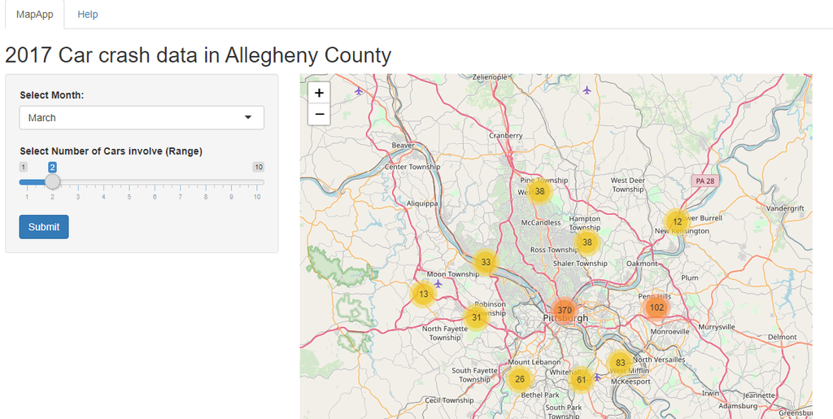